# Data 624 - Project 1

## Part C – BONUS, optional (part or all)

Part C consists of two data sets. These are simple 2 columns sets, however they have different time stamps. Your optional assignment is to time-base sequence the data and aggregate based on hour (example of what this looks like, follows). Note for multiple recordings within an hour, take the mean. Then to determine if the data is stationary and can it be forecast. If so, provide a week forward forecast and present results via Rpubs and .rmd and the forecast in an Excel readable file.

### Prepare the data

```r
head(water1)
```

| Date Time | WaterFlow |
| --- | --- |
| 2015-10-23 00:24:06 | 23.369599 |
| 2015-10-23 00:40:02 | 28.002881 |
| 2015-10-23 00:53:51 | 23.065895 |
| 2015-10-23 00:55:40 | 29.972809 |
| 2015-10-23 01:19:17 | 5.997953 |
| 2015-10-23 01:23:58 | 15.935223 |

```r
head(water2)
```

| Date Time | WaterFlow |
| --- | --- |
| 2015-10-23 01:00:00 | 18.81079 |
| 2015-10-23 02:00:00 | 43.08703 |
| 2015-10-23 03:00:00 | 37.98770 |
| 2015-10-23 04:00:00 | 36.12038 |
| 2015-10-23 05:00:00 | 31.85126 |
| 2015-10-23 06:00:00 | 28.23809 |

```r
#join them
water <- rbind(water1,water2)

#sort data
water <- water[order(as.Date(water$`Date Time`, format="%Y-m%-d% h%:M%:s%")),]

#aggragate by hour and take mean...
water <- water %>%
  separate(`Date Time`, into = c("date", "time"), sep = " ") %>%
  separate(time, into = c("hour", "minute", "seccond"), sep = ":") %>%
  group_by(date, hour) %>%
  summarise(mean(WaterFlow,na.rm = T)) %>%
  ungroup() %>%
  arrange() %>%
  collect() %>%
  `colnames<-`(c("date", "time", "WaterFlow"))

#create timeseries
water.ts <- ts(water$WaterFlow,frequency=24)
```

### Inspect the data

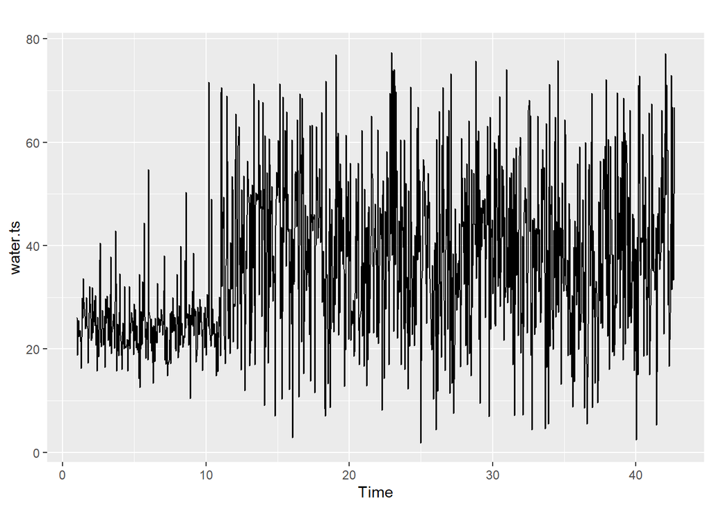

```r
autoplot(water.ts)
```

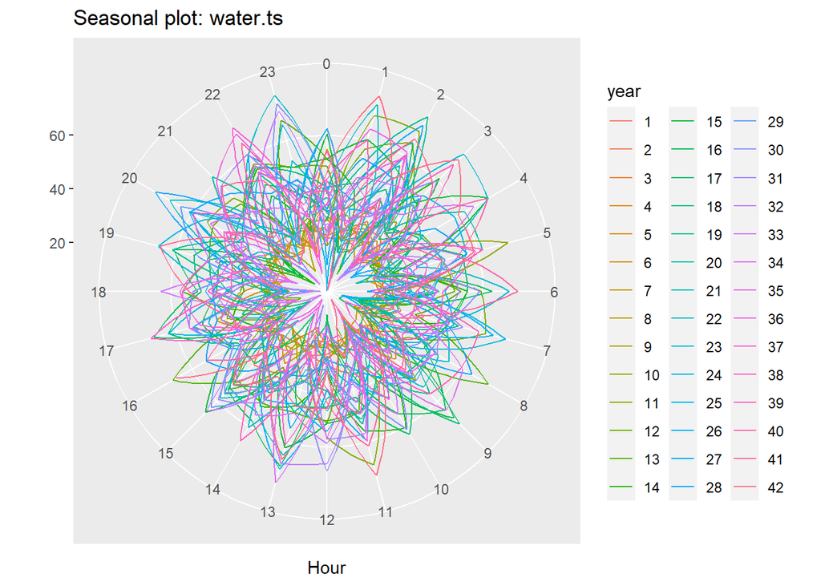

```r
ggseasonplot(water.ts,polar=T )
```

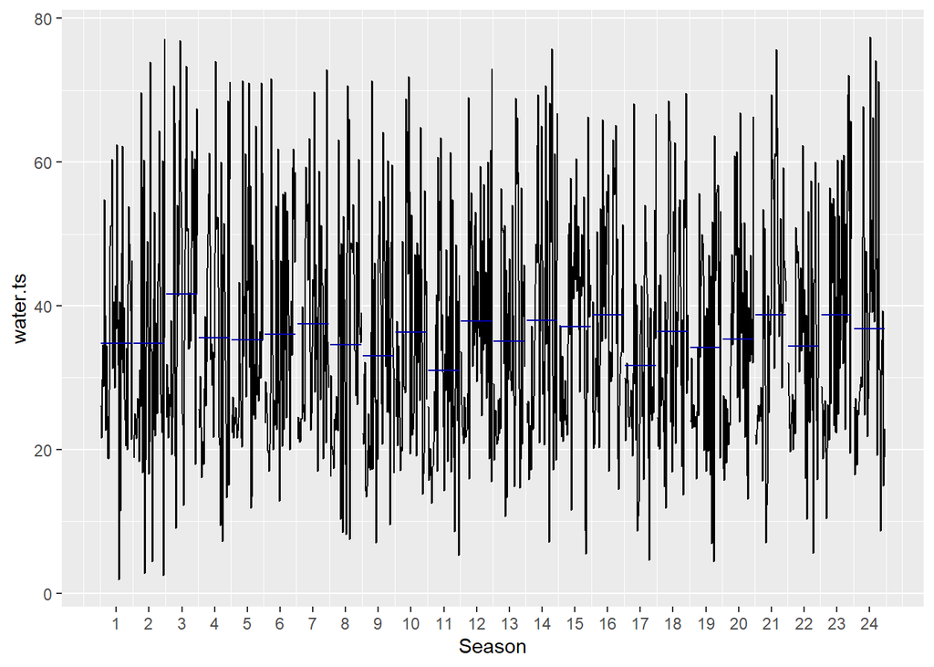

```r
ggsubseriesplot(water.ts )
```